# Sexual Offenses and Alcohol Abuse at Pennsylvania State University Campuses

Sarah Kircher, Leigh Stern, and Nathanael Kovscek

2022-12-14

# Introduction

Sexual assault and drinking are often thought of as being connected. Put in another way, where there is more alcohol, there is more assault. We wish to explore this established pattern and see if it exists here at Penn State.  
In this document, we gathered data from Penn State Pulse surveys and Clery Act releases to explore the relationship between alcohol use and sexual assault in our community. In addition, we explore how University Park compares to the aggregation of the top three branch campuses: Abington, Erie, and Harrisburg. What follows are some questions we are trying to answer:

1. How has the number of Penn State students who report consuming any alcohol changed over time?
2. How does high-risk drinking of Penn State students vary over time by sex?
3. How do the effects of alcohol impact Penn State student experiences with sexual assault over time?
4. How do sexual assault trends differ at branch campus from main campus?

# Data Background

## Penn State PULSE Survey

Alcohol consumption, high-risk drinking, and the consequences related to drinking behaviors at Penn State are major problems that need to be addressed to maintain the safety and security of students on and off campus. In order to get an accurate representation of alcohol consumption and other related data from Penn State students, we chose to investigate public data released from the Penn State PULSE survey.

The Penn State PULSE survey began administration in 1995, and it covers a wide range of topics, including the arts, sustainability, drinking, communications, diversity and inclusion, food and housing, and new students. The survey is administered by the Student Affairs Research and Assessment (SARA) about two to four times a year. The PULSE surveys help Penn State administrators understand the concerns, needs, and experiences of students over different topics.

Currently, the PULSE surveys are sent via email to a random sample of Penn State students. Occasionally, a specific population is chosen depending on the topic of the survey, and then a random sample is pulled from the specific population. The survey response rate percentages vary from teens to low twenties due to the survey topic. For each survey, the student characteristics of respondents are compared to the population characteristics in order to determine if the sample appropriately represents the population.

## Drinking PULSE Survey and Data

The Drinking PULSE Survey is used to obtain information on Penn State students’ alcohol consumption, high-risk drinking behaviors, and consequences of alcohol use on different aspects of their lives as college students. In our report, we will focus on the alcohol consumption of Penn State students, the difference in high-risk drinking behaviors between the sexes, and the sexual consequences of drinking behaviors over time.

For the Drinking PULSE Survey data, it is important to note that the surveys have only been administered online since 2009. Before 2009, surveys were conducted by phone or online at the request of the University Health Services. This could have affected the number of survey respondents over time.

Before visualizing the data, it was necessary to observe the structure of the data provided by the Penn State Drinking PULSE Survey. First, we found that the Drinking PULSE Survey is not conducted consistently, which is noticeable in the bar graph of high-risk drinking behaviors by sex over time. Since 2011, the Drinking PULSE Survey has been conducted every other year.

In addition to this, we discovered that Penn State’s reports of this drinking data are misleading. For the alcohol consumption and high-risk drinking behaviors by sex data sets, the data is structured with time increasing from left to right, since the percentages decrease over time. We believed that this structure would have continued throughout the Drinking PULSE Survey report, but this is not the case. For the consequences of drinking behaviors data, the percentages in most categories increase over time, so the data is arranged from the most recent collection (2019) to the oldest collection (2010), which makes the data appear to be decreasing over time rather than increasing. Because of the inconsistencies between the data sets, Penn State’s report of the Drinking PULSE survey data is misleading.

# Population Analysis

Before we take a look at the survey results about drinking and the crime reports from Clery data, we find it prudent to first present an overview of enrollment Penn State. This will serve as a baseline to understanding the other data we will present.  
To do this, we’ve taken data releases from Penn State’s Data Digest initiative. Specifically, we look at the enrollment data that is provided. After applying some initial filters available on the website, we downloaded the data into a csv file. This data was not in a tidy format so part of the process was wrangling it into a good format. One thing to note here is that, all students - including graduate and law students - are included in the graphs that follow.

## University Park Enrollment

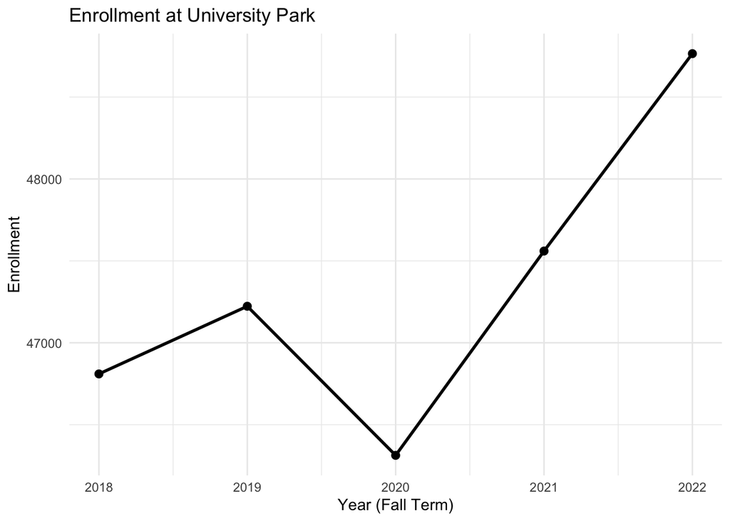

```r
# Create the visualization
UP_enroll <- ggplot(enrollment_data, aes(FallYear, UniversityPark)) +
  geom_line(size = 1) + geom_point(size = 2.25) +

  # Add updated labels
  labs(title = "Enrollment at University Park",
       y = "Enrollment",
       x = "Year (Fall Term)") +

  # Change the sizes of the labels
  theme(title = element_text(size = 16),
        axis.title = element_text(size = 14)) +

  theme_minimal()

UP_enroll
```

In the last five years, the University Park campus has seen an increase in the number of students enrolled at the university. Between 2018 and 2022, there is an approximately 2000 student difference in size.

Additionally, we see that in 2020, there was a rather steep drop in the number of students who were enrolled. It seems reasonable to attribute this to the COVID pandemic and that the enrollment recovery was quite good.

## Branch Campus Enrollment

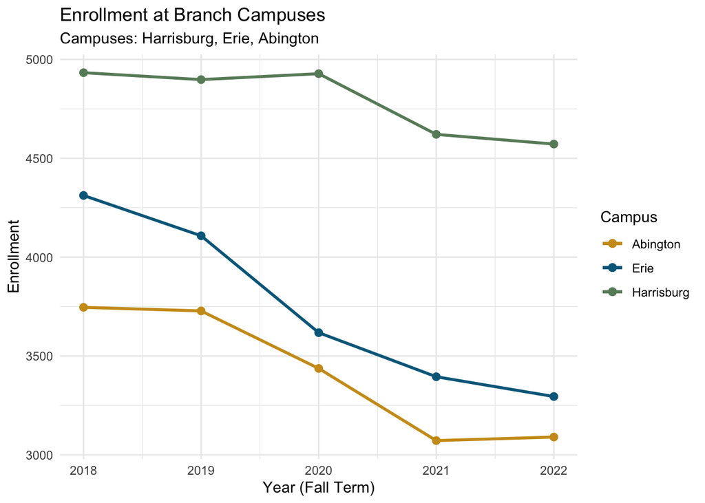

```r
# Colors for Campus lines
campus_colors <- c("Abington" = "goldenrod3",
                                 "Erie" = "deepskyblue4",
                                 "Harrisburg" = "darkseagreen4")
# Each Branch Campus Individually
top3_enroll <- ggplot(enrollment_data, aes(FallYear)) +

  # Add the marks to the visualization
  geom_line(aes(y = Abington, color = 'Abington'), size = 1) +
  geom_line(aes(y = Erie, color = 'Erie'), size = 1) +
  geom_line(aes(y = Harrisburg, color = 'Harrisburg'), size = 1) +
  geom_point(aes(y = Abington, color = 'Abington'), size = 2.25) +
  geom_point(aes(y = Erie, color = 'Erie'), size = 2.25) +
  geom_point(aes(y = Harrisburg, color = 'Harrisburg'), size = 2.25) +

  # Add custom color scale for the campus color lines
  scale_color_manual(values = campus_colors) +

  # Adding titles and new labels
  labs(title = "Enrollment at Branch Campuses",
       subtitle = "Campuses: Harrisburg, Erie, Abington",
       x = "Year (Fall Term)",
       y = "Enrollment",
       color = "Campus") +

  # Updating font sizes and line colors
  theme(axis.title = element_text(size = 14),
        title = element_text(size = 16)) +

  theme_minimal()

top3_enroll
```

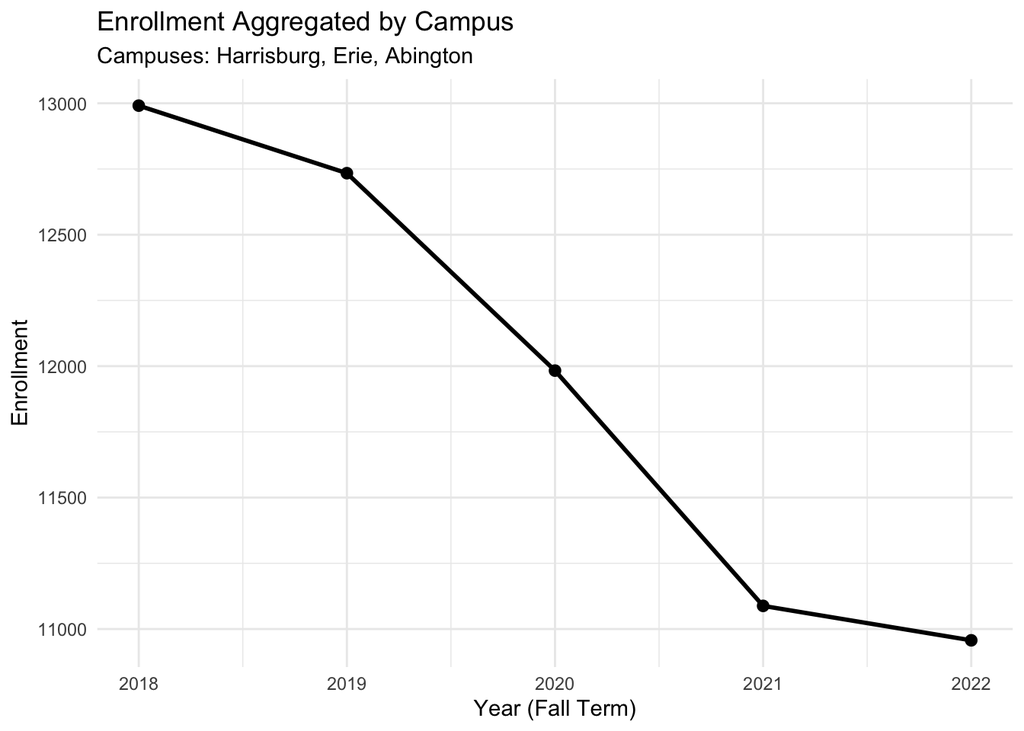

```r
# Filtering the table to only include the sum of each branch campus by year
top3 <- select(enrollment_data, -UniversityPark)
top3$branch_enrollment <- rowSums(top3[,c(-1)])

# Create the visualization
top3_agg_enroll <- ggplot(top3, aes(FallYear, branch_enrollment)) +
  geom_line(size = 1) +
  geom_point(size = 2.25) +

  # Add updated titles
  labs(title = "Enrollment Aggregated by Campus",
       subtitle = "Campuses: Harrisburg, Erie, Abington",
       x = "Year (Fall Term)",
       y = "Enrollment") +

  # Update font sizes
  theme(title = element_text(size = 16),
    axis.title = element_text(size = 14)) +

  theme_minimal()

top3_agg_enroll
```

The branch campuses that we are observing will be the campuses at Harrisburg, Erie, and Abington. We’ve chosen these branches because they are the three largest branch campuses of Penn State.

In the past five years, branch campuses have seen a decrease in their enrollment. This is not solely due to the pandemic as some might think, but rather, seems to have been a trend that had already started by 2018.

With these trends now observed, we will start our look into the Penn State Pulse Data.

# University Park Cases

```r
# Load dataset 1 from Excel - PSU student alcohol consumptions
alcohol_consumption <- read_excel("~/Documents/GitHub/FP_Sarah_Leigh_Nathanael/data/PSU_students_report_consuming_alc.xlsx")

# Load dataset 2 from Excel - PSU student high risk drinking by sex
hr_drinking_sex <- read_excel("~/Documents/GitHub/FP_Sarah_Leigh_Nathanael/data/PSU_high_risk_drinking_sex.xlsx")

# Load dataset 3 from Excel - PSU student drinking consequences
drinking_consequences <- read_excel("~/Documents/GitHub/FP_Sarah_Leigh_Nathanael/data/PSU_drinking_consequences.xlsx")
```

## How has the number of Penn State students who report consuming any alcohol changed over time?

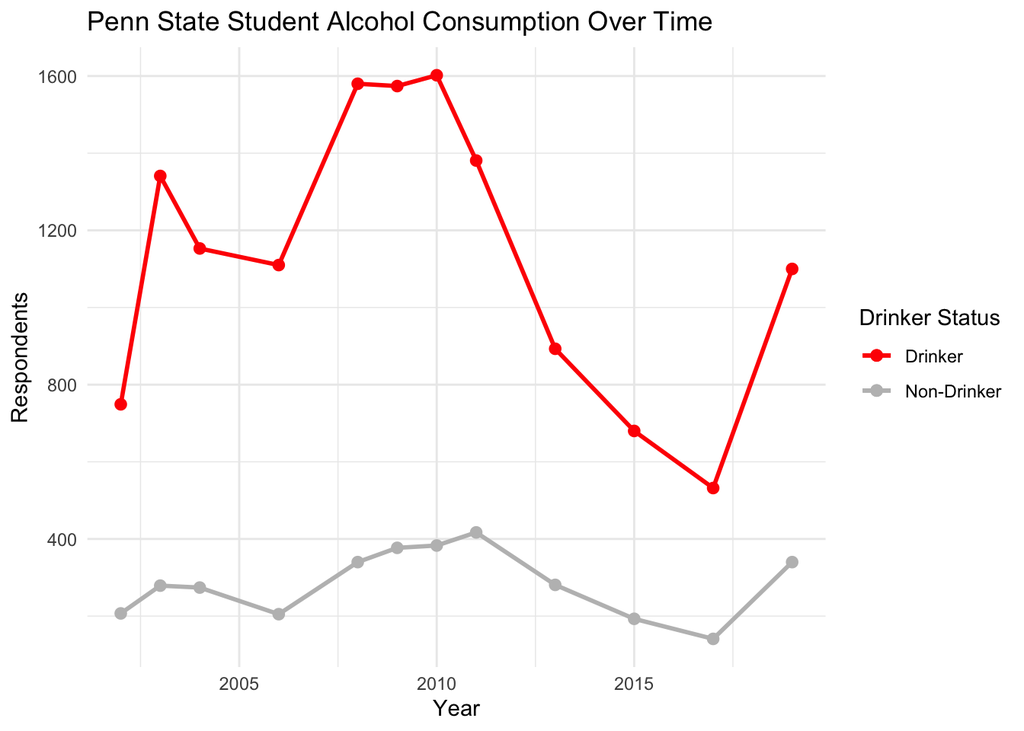

```r
# Create ggplot2 line graph for PSU student alcohol consumption over time
# One line/trend for respondents who do drink - red
# One line/trend for respondents who do not drink - gray
alc_consump_colors <- c("Drinker" = "red", "Non-Drinker" = "gray")

ggplot(
  data = alcohol_consumption,
  aes(x = year)
) +
# Create points on each line
  geom_point(aes(y = drink_num, color = "Drinker"), size = 2.25) +
  geom_point(aes(y = not_drink_num, color = "Non-Drinker"), size = 2.25) +

 # Create one line for each drinker status
  geom_line(aes(y = drink_num, color = "Drinker"), size = 1) +
  geom_line(aes(y = not_drink_num, color = "Non-Drinker"), size = 1) +

  # Add axis labels, title, and colors
  labs(x = "Year", y = "Respondents", color = "Drinker Status") +
  ggtitle("Penn State Student Alcohol Consumption Over Time") +
  scale_color_manual(values = alc_consump_colors) +
  theme_minimal()
```

This plot addresses the question “how has the number of Penn State students who report consuming any alcohol changed over time?” The x-axis represents the year, and the y-axis represents the number of survey respondents. The red line represents students who reported alcohol consumption in the given year, and the gray line represents students who reported no alcohol consumption in the given year. The points on the lines represent the Drinking PULSE survey collections. The inconsistency of the administration of the drinking PULSE survey can be seen by the variety of spread of data points along each line.

Clearly, the number of respondents who report consuming alcohol is consistently larger than the number of respondents who report not consuming alcohol from 2002 to 2019. It is interesting to observe the trend of respondents who report consuming alcohol over time. There is a clear decrease in respondents who report alcohol consumption from 2010 to 2017. In 2010, about 1600 respondents report consuming alcohol, and in 2017, about 550 respondents report consuming alcohol. Then, in 2019, about 1100 respondents report consuming alcohol. What could have caused this large decrease from 2010-2017 and then immediate increase from 2017-2019?

## How does high-risk drinking of Penn State students vary over time by sex?

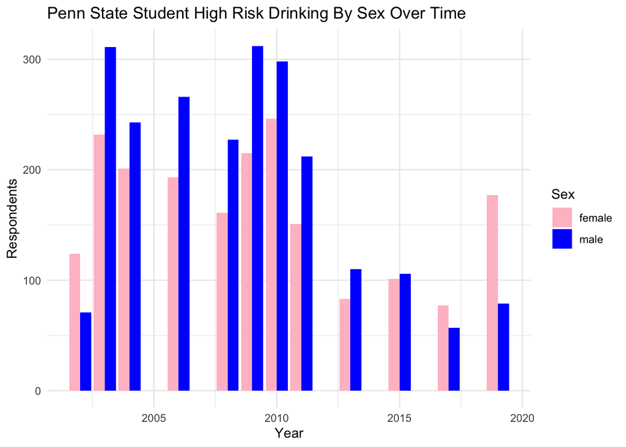

```r
# Creates grouped bar chart for PSU high-risk drinking by sex over time
# A pair of bars for each survey collection year
# Blue bars for male respondents
# Pink bars for female respondents

ggplot(
  data = hr_drinking_sex,
  aes(x = year,
      y = frequency,
      fill = sex)) +

 # Set the position of the bars
  geom_bar(stat = "identity", position = 'dodge') +

 # Add a title, axis labels, and colors
  labs(x = "Year", y = "Respondents", fill = "Sex") +
  ggtitle("Penn State Student High Risk Drinking By Sex Over Time") +
  scale_fill_manual(values = c("pink", "blue")) +
  theme_minimal()
```

This plot addresses the question “How does high-risk drinking of Penn State students vary over time by sex?” The x-axis represents the year, and the y-axis represents the number of survey respondents. The pink bars represent females, and the blue bars represent males. The lengths of the bars represent the number of respondents who reported high-risk drinking. Each pair of bars represent a survey collection in the corresponding year. The inconsistency of the administration of the drinking PULSE survey can be seen by the spread of the bars as well as the breaks between bar pairs.

According to the National Institute on Alcohol Abuse and Alcoholism (NIAAA), high-risk drinking is defined as 14 drinks per week for men and 7 drinks per week for women. Looking at the bar chart, a greater number of men reported high-risk drinking compared to women in most survey collections from 2002 to 2019. In 2002, 2017, and 2019, a greater number of women reported high-risk drinking compared to men. Even though the number of respondents are different, the overall trend of the bar chart matches the trend of the red drinker status line from the previous time series graph on alcohol consumption. It is interesting to note the most recent change in high-risk drinking rates for women. In 2019, the number of women who report high-risk drinking is more than two times the number of men who report high-risk drinking. What could have caused this drastic increase in high-risk drinking rates for the female sex?

## How do the effects of alcohol impact Penn State student experiences with sexual assault over time?

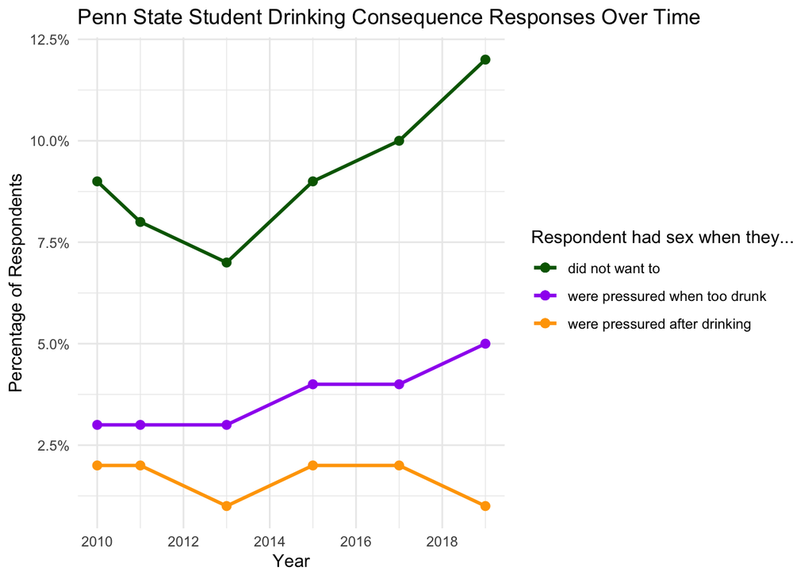

```r
# Create ggplot2 line graph for drinking consequences over time - sexual assault
# Green line for "Had sex when you didn’t really want to"
# Purple line for "Been pressured or forced to have sex with someone and were too drunk to prevent it"
# Orange line for "Pressured or forced someone to have sex with you after you had been drinking"
consequence_colors <- c("did not want to" = "dark green",
                                 "were pressured when too drunk" = "purple",
                                 "were pressured after drinking" = "orange")
ggplot(
  data = drinking_consequences,
  aes(x = year)
) +

# Create points on each line
  geom_point(aes(y = sex_did_not_want, color = "did not want to"), size = 2.25) +
  geom_point(aes(y = pressured_forced_drunk, color = "were pressured when too drunk"), size = 2.25) +
  geom_point(aes(y = pressured_forced_after_drinking, color = "were pressured after drinking"), size = 2.25) +

# Create three lines - one for each sexual assault consequence
  geom_line(aes(y = sex_did_not_want, color = "did not want to"), size = 1) +
  geom_line(aes(y = pressured_forced_drunk, color = "were pressured when too drunk"), size = 1) +
  geom_line(aes(y = pressured_forced_after_drinking, color = "were pressured after drinking"), size = 1) +

# Add axis labels, title, and colors
  labs(x = "Year", y = "Percentage of Respondents", color = "Respondent had sex when they...") +
  ggtitle("Penn State Student Drinking Consequence Responses Over Time") +
  scale_color_manual(values = consequence_colors) +

# Add percent signs to y-axis labels and set manual breaks in x-axis
  scale_y_continuous(labels = scales::percent) +
  scale_x_continuous(breaks = c(2010, 2012, 2014, 2016, 2018, 2020)) +
  theme_minimal()
```

This plot addresses the question “how do the effects of alcohol impact Penn State student experiences with sexual assault over time?” The x-axis represents the year, and the y-axis represents the percentage of survey respondents. Each line represents a different consequence of alcohol consumption related to sexual assault over time. The dark green line represents the percentage of respondents that had sex when they did not want to. The purple line represents the percentage of respondents that had sex when they were pressured into it when they were too drunk. The orange line represents the percentage of respondents that had sex when they were pressured into it after drinking.

There is a slight increase in the percentage of respondents (from three to five percent) that were drunk and pressured into having sex from 2010 to 2019. There is fluctuation in the percentage of respondents (between one and two percent) that were pressured into having sex after drinking between 2010 and 2019. The percentage of respondents that sex when they did not want to is significantly larger compared to the other two drinking consequences. In addition to this, from 2013 to 2019, the percentage of respondents in this category of had sex when they did not want to continues to increase. With alcohol consumption of Penn State students increasing since 2019, could both of these increases be related?

# Campus Sexual Assault Cases

This data was pulled from Clery statistics published yearly by Penn State.The goal was to better understand the incidence of sexual assaults (i.e. rape and fondling reports) on the University Park campus as compared to the aggregated data for Penn State’s largest branch campuses (Abington, Erie, and Harrisburg).

```r
CleryData3 <- read_excel("~/Documents/GitHub/FP_Sarah_Leigh_Nathanael/data/CleryData3.xlsx")
#Loading the data we have pulled from Penn State's campus Clery reports. This particular Excel summarizes the data from all On- and Off-Campus rape and fondling incidences reported from 2017-2021 at University Park.

#Creating a table of all On-Campus sexual assault incidences from 2017-2021 and finding the totals for each type of incidence and the years.
cleryTable2017 <- CleryData3 %>%
  filter(Location == "On-Campus Property") %>%
  tabyl(Type, Year) %>%
  adorn_totals(where = c("row", "col")) %>%
  adorn_title(
    placement = "combined",
    row_name = "Type",
    col_name = "Year"
  )

#Cleaning the table

cleryTable2017 %>%
  kable(
    caption = "On-Campus UP Property Sexual Offences"
  ) %>%
  kableExtra::kable_styling(
    bootstrap_options = c("striped"),
    font_size = 14
  ) %>%
  kableExtra::column_spec(1:6, color = "black") %>%
  kableExtra::row_spec(1:3, color = "black")
```

On-Campus UP Property Sexual Offences

| Type/Year | 2017 | 2018 | 2019 | 2020 | 2021 | Total |
| --- | --- | --- | --- | --- | --- | --- |
| Fondling | 20 | 27 | 24 | 13 | 22 | 106 |
| Rape | 37 | 49 | 41 | 28 | 41 | 196 |
| Total | 57 | 76 | 65 | 41 | 63 | 302 |

```r
#Loading the data we have pulled from Penn State's campus Clery reports. This particular Excel summarizes the data from all On- and Off-Campus rape and fondling incidences reported from 2017-2021 at University Park.
CleryData3 <- read_excel("~/Documents/GitHub/FP_Sarah_Leigh_Nathanael/data/CleryData3.xlsx")

#Creating a table of all Off-Campus sexual assault incidences from 2017-2021 and finding the totals for each type of incidence and the years.
cleryTableOffUP <- CleryData3 %>%
  filter(Location == "Non Campus") %>%
  tabyl(Type, Year) %>%
  adorn_totals(where = c("row", "col")) %>%
  adorn_title(
    placement = "combined",
    row_name = "Type",
    col_name = "Year"
  )

#Cleaning the table

cleryTableOffUP %>%
  kable(
    caption = "Off UP Campus Sexual Offences"
  ) %>%
  kableExtra::kable_styling(
    bootstrap_options = c("striped"),
    font_size = 14
  ) %>%
  kableExtra::column_spec(1:6, color = "black") %>%
  kableExtra::row_spec(1:3, color = "black")
```

Off UP Campus Sexual Offences

| Type/Year | 2017 | 2018 | 2019 | 2020 | 2021 | Total |
| --- | --- | --- | --- | --- | --- | --- |
| Fondling | 1 | 6 | 19 | 0 | 5 | 31 |
| Rape | 16 | 20 | 29 | 10 | 7 | 82 |
| Total | 17 | 26 | 48 | 10 | 12 | 113 |

```r
CleryDataOtherCampuses <- read_excel("~/Documents/GitHub/FP_Sarah_Leigh_Nathanael/data/CleryDataOtherCampuses.xlsx")
#Loading the data we have pulled from Penn State's campus Clery reports. This particular Excel summarizes the data from all On- and Off-Campus rape and fondling incidences reported from 2017-2021 at the Abington, Erie, and Harrisburg campuses.
#Incidences at all of these campuses are aggregated per year.

#Creating a table of all Off-Campus sexual assault incidences from 2017-2021 and finding the totals for each type of incidence and the years.

cleryTableBranchOn <- CleryDataOtherCampuses %>%
  filter(Location == "On-Campus Property") %>%
  tabyl(Type, Year) %>%
  adorn_totals(where = c("row", "col")) %>%
  adorn_title(
    placement = "combined",
    row_name = "Type",
    col_name = "Year"
  )

#Cleaning the table

cleryTableBranchOn %>%
  kable(
    caption = "Branch Campuses Sexual Offences"
  ) %>%
  kableExtra::kable_styling(
    bootstrap_options = c("striped"),
    font_size = 14
  ) %>%
  kableExtra::column_spec(1:5, color = "black") %>%
  kableExtra::row_spec(1:3, color = "black")
```

Branch Campuses Sexual Offences

| Type/Year | 2017 | 2018 | 2019 | Total |
| --- | --- | --- | --- | --- |
| Fondling | 3 | 0 | 2 | 5 |
| Rape | 4 | 10 | 4 | 18 |
| Total | 7 | 10 | 6 | 23 |

Each of these tables show the trends of sexual assaults over time as well as well as highlighting the differences between the rate at which these incidents occur on- and off-campus.

For example, in comparing the two tables related University Park, it becomes abundantly clear that the number of sexual assault incidents is significantly lower off-campus. This trend suggests most environments where these events occur tend to be on-campus, likely in areas such as dorm halls. The one outlier from that data set appears to be in the year 2019, when the number of sexual assault incidents jumped to 48 – significantly higher than in any of the years before or after that.

It is also worth paying attention to the comparatively low numbers of sexual assault incidences on branch campuses. Because these values are so small, the team decided to aggregate the data from Penn State’s three largest branch campuses: Abington, Erie, and Harrisburg. Even put together as they are, the frequency of these incidences does not compare with the number of reports for either on- or off-campus at University Park.

# Conclusion

Having presented our exploratory data analysis, we can see that, when a greater percentage of PULSE poll respondents said they consumed alcohol in the given time period, there was a greater number of reported sexual assaults. This, purportedly affirms the established connection between alcohol and assault that was originally postulated.

However, just because those two things are correlated, that does not imply that it was merely more people drinking that was the problem. An additional explanation for this pattern is that there were more students enrolled at the times in which sexual assault was reported more. This is particularly evident in the data tables. When there is an increase in the enrollment body at University Park, there is an increase in the number of reported sexual assaults. It’s not perfectly true, but the pattern does exist and thus is likely part of the explanation for what variables affect the rate of sexual assault at Penn State.